# Resultados por município

# Palmela

Segundo o Inquérito à Mobilidade ([IMob 2018](https://www.ine.pt/xportal/xmain?xpid=INE&xpgid=ine_publicacoes&PUBLICACOESpub_boui=349495406&PUBLICACOESmodo=2&xlang=pt)) realizado em 2017 pelo INE, as viagens com origem e/ou destino em Palmela têm as seguintes características:

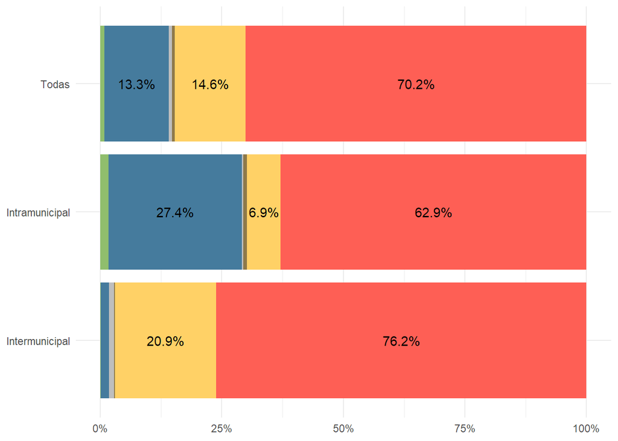

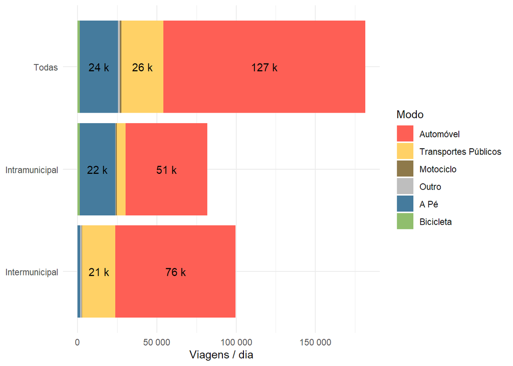

Das cerca de 181mil viagens diárias em Palmela, apenas **0.8% das viagens são realizadas em bicicleta** (1498). 127mil são feitas em automóvel (70.2%), 24mil a pé (13.3%), 26mil em Transportes Públicos (14.6%) e 2 079 em outros modos (1.2%).

Diariamente, cerca de 82mil viagens têm origem e destino em Palmela, e cerca de 100mil viagens têm origem ou destino em municípios diferentes.

## Rede ciclável potencial

Os mapas seguintes mostram as ligações cicláveis com maior potencial, para o **cenário base** (viagens do IMob 2018), para **4%** de viagens em bicicleta (meta 2025), e para **10%** de viagens em bicicleta (meta 2030), transferidas diretamente de viagens em automóvel.

Cada mapa refere-se a cada uma das 3 estimativas:

- viagens até 5 km com ligação em bicicleta (*33 474 viagens em Palmela*)
- viagens até 10 km com ligação em bicicleta elétrica (*71 904 viagens em Palmela*)
- viagens até 5 km em bicicleta até ou desde uma interface de transportes (*11 458 viagens em Palmela*)

**Como ler estes mapas?**

Os mapas apresentam a informação gráfica para duas redes - a rede ciclável para viagens mais diretas, e a rede para viagens mais seguras e tranquilas (conforme a rede viária existente).  
A largura das linhas varia consoante o número de ciclistas potencial para cada um dos cenários (4% e 10% de ciclistas), e essa informação é visível ao passar com o rato em cima da linha.  
A cor das linhas varia com o nível de tranquilidade ([*quietness*](https://www.cyclestreets.net/help/journey/howitworks/#quietness)), sendo as mais escuras aquelas menos seguras para circular em bicicleta - indicando com maior clareza quais os segmentos que necessitam de intervenção para se tornarem mais seguros e potencialmente trazerem mais ciclistas: os **mais escuros e mais largos**.

Ao clicar em cada linha, uma janela abre-se com mais informação sobre as viagens estimadas que podem passar por aquele segmento, incluindo os benefícios sociais e ambientais estimados, e as características físicas daquele segmento.

É possível ver mais do que uma opção de rota em simultâneo (direta / segura), por exemplo para comparar alternativas, e níveis de potencial ciclável, estabelecidos pela Estratégia Nacional de Mobilidade Ativa Ciclável ([ENMAC](https://files.dre.pt/1s/2019/08/14700/0004600081.pdf)), em 4 e 10% nos centros urbanos, transferidos de viagens em automóvel.

#### Até 5 km

Este mapa apresenta os segmentos com mais de 15 viagens potenciais em bicicleta. Para um maior ou menor detalhe da rede, ver a secção de Downloads.

[interactive chart not shown]

Vendo o mapa em ecrã inteiro é possível comparar os resultados com a rede existente e planeada.

#### Até 10 km (e-bike)

Este mapa mostra os segmentos com mais de 50 viagens potenciais em bicicleta elétrica. Para um maior ou menor detalhe da rede, ver a secção de Downloads.

[interactive chart not shown]

Ver mapa em ecrã inteiro.

#### Até 5 km intermodal

Este mapa mostra os segmentos com mais de 10 viagens potenciais em bicicleta, em que parte da viagem é realizada em transportes públicos (barco, comboio, metro sul do Tejo, ou Carris Metropolitana). Os segmentos deste mapa dizem respeito apenas à parte da viagem que é realizada em bicicleta, num total de até 5 km no conjunto da primeira e última etapa da viagem intermodal. Para um maior ou menor detalhe da rede, ver a secção de Downloads.

[interactive chart not shown]

Ver mapa em ecrã inteiro.

## Resumo

A tabela mostra o potencial ciclável em Palmela em número de novas viagens em bicicleta potenciais diárias, para cada meta da Estratégia Nacional ENMAC (4% e 10%), para cada um dos três cenários, e para cada tipo de rotas otimizadas.

Para cada um destes cenários, é possível ver também de forma agregada qual o benefício potencial estimado, em toneladas de CO<sub>2</sub>eq evitado anualmente, e em benefícios sociais.

**Como são estimados os benefícios sociais e ambientais?**

Os benefícios potenciais são estimados em duas vertentes, utilizando os métodos e a ferramenta [*HEAT for Cycling*](https://www.heatwalkingcycling.org/), da Organização Mundial de Saúde.

A componente ambiental é medida em toneladas de CO<sub>2</sub>eq evitado, por transferência de viagens equivalentes em automóvel, com a mesma origem e destino, mas não necessariamente com o mesmo percurso.

Os impactes sociais agregados, na componente da saúde, são estimados em termos de redução/aumento da mortalidade por aumento de atividade física, por exposição à poluição atmosférica, e por exposição ao risco de sinistralidade rodoviária.  
Este valor é por fim monetizado utilizando o *Valor Estatístico da Vida* (€3.055.358, segundo [ANSR 2021](http://www.ansr.pt/Estatisticas/RelatoriosTematicos/Documents/O%20Impacto%20Economico%20e%20Social%20da%20Sinistralidade%20-%20PT.pdf)), estimado para 10 anos, com uma taxa de desconto de 5% e inflação de 3%.

| Meta ENMAC | Cenário | Tipo de Percurso | Total Viagens /dia | Viagens Bicicleta Base | Viagens Bicicleta Potencial | CO2eq evitado (ton/ano) | Benefícios estimados em 10 anos (milhares €) |
| --- | --- | --- | --- | --- | --- | --- | --- |
| 4% | até 5 km | seguro | 29400 | 519 | 687 | 69.1 | 3365.9 |
| 4% | até 5 km | direto | 33474 | 580 | 790 | 85 | 3936.1 |
| 4% | até 10km e-bike | seguro | 64244 | 955 | 1675 | 314.5 | 14660 |
| 4% | até 10km e-bike | direto | 71904 | 1013 | 1932 | 404.9 | 16950 |
| 4% | intermodal até 5km | seguro | 14769 | 72 | 519 | 74.1 | 3002.5 |
| 4% | intermodal até 5km | direto | 11458 | 10 | 448 | 68 | 2795.3 |
| 10% | até 5 km | seguro | 29400 | 519 | 2421 | 245.8 | 11679 |
| 10% | até 5 km | direto | 33474 | 580 | 2768 | 300.3 | 13582 |
| 10% | até 10km e-bike | seguro | 64244 | 955 | 5469 | 976.3 | 46427 |
| 10% | até 10km e-bike | direto | 71904 | 1013 | 6178 | 1216.5 | 52171 |

[output cut: 2 more lines]

Em Palmela, a **meta de 4%** de ciclistas diários equivale a ter **1 932 ciclistas** em viagens até 10 km, com uma redução potencial de **405 toneladas** de CO<sub>2</sub>eq por ter menos viagens em automóvel na mesma razão, com potenciais benefícios para a sociedade de **17 milhões €** ao fim de 10 anos.

Já a **meta de 10%** de ciclistas diários equivale a ter **6 178 ciclistas** em viagens até 10 km, com uma redução potencial de **1 216 toneladas** de CO<sub>2</sub>eq por ter menos viagens em automóvel na mesma razão, com potenciais benefícios para a sociedade de **52 milhões €** ao fim de 10 anos.

## Downloads

Os mapas acima estão disponíveis para download, em formato *GeoPackage* (.gpkg), que pode ser lido em qualquer SIG moderno. É recomendável o software de acesso livre [QGIS](https://qgis.org/pt_PT/site/) para leitura, visualização e análise de dados em detalhe.

1. **Viagens até 5 km em bicicleta**
- Rede direta
- Rede segura
2. **Viagens até 10 km em bicicleta elétrica**
- Rede direta
- Rede segura
3. **Viagens intermodais até 5 km em bicicleta**
- Rede direta
- Rede segura

Para cada município, os dados disponíveis para download referem-se à rede ciclável potencial com uma margem de 300 metros para além dos limites do município, para que sejam consideradas as ligações ao município vizinho. (*Exceto no cenário 3*)

🔎 A rede disponibilizada poderá não corresponder à que é apresentada nos mapas acima, que mostram apenas os segmentos com mais de X viagens potenciais em bicicleta. Para visualizar os segmentos dependendo do número de viagens potenciais, utilizar os filtros do SIG, por exemplo, para visualizar só os segmentos com mais de 500 viagens, ou todos os segmentos com mais de 10 viagens em bicicleta.